# Getting started with vbayesGP

Seongil Jo and Woojoo Lee

2026-10-04

vbayesGP fits Bayesian semiparametric regression models in which a set of exposures enters through a Gaussian process surface, by Gaussian variational approximation. The outcome can be continuous, binary or a count; the exposures can enter through one kernel or through several weighted indices; and cluster-level random intercepts and slopes can be added to every model. The fitting functions are

| outcome | one kernel | several indices |
| --- | --- | --- |
| continuous | `gvagpr()` | `gvagpmim()` |
| binary or count | `gvaggpr()` | `gvaggpmim()` |

Everything downstream – summaries, fitted surfaces, predictions, exposure-response curves, overall and single-exposure risks, inclusion probabilities, random effects and the evidence lower bound – works the same way on all four.

This vignette walks through each of them on simulated data. The data sets are small (two hundred observations) and some optimiser runs are capped so that the document builds in a few minutes; drop the `control` arguments for a real analysis and let the stopping rule decide.

```r
library(vbayesGP)
```

## Simulated data

Four exposures, one covariate, and a surface that depends on the first two exposures only: a quadratic in each, with an interaction. The third and fourth exposures are noise, which is what the inclusion probabilities should find. (A purely linear effect is a long length-scale to the kernel, and the shrinkage prior on the length-scales reads it as weak; the surfaces the package is meant for are the curved ones.)

```r
set.seed(2026)
n <- 200
Z <- matrix(runif(n * 4, -1, 1), n, 4, dimnames = list(NULL, c("As", "Cd", "Pb", "Hg")))
X <- cbind(age = rnorm(n))
h <- 2 * Z[, "As"]^2 - 1.5 * Z[, "Cd"]^2 + Z[, "As"] * Z[, "Cd"]
h <- h - mean(h)
y <- 0.5 * X[, "age"] + h + rnorm(n, sd = 0.5)
```

## A continuous outcome: `gvagpr()`

```r
fit <- gvagpr(y, X, Z, minibatch = FALSE, verbose = FALSE, seed = 1)
fit
```

```
#> Fitted object of class 'gpr'
#> Outcome family: gaussian
#> Covariance structure: diagonal
#> Lengthscale Parameter: varying
#> Iterations: 5447
#> Running time: 9.184 secs
#> Model fit on: 2026-10-04 23:57:58.308139
```

`summary()` gives the coefficient of the covariate, the residual variance, the amplitude of the surface and the length-scale of each exposure, each with a credible interval from the variational posterior.

```r
summary(fit)
```

```
#> Fitted object of class 'gpr'
#> Outcome family: gaussian
#> Covariance structure: diagonal
#> Lengthscale Parameter: varying
#> Iterations: 5447
#> Running time: 9.184 secs
#> Model fit on: 2026-10-04 23:57:58.326103
#>
#> Parameter estimates:
#>              mean      sd   q_2.5    q_50   q_97.5
#> beta      0.49283 0.03276 0.42963 0.49209  0.55645
#> sigsq.eps 0.21609 0.02326 0.17195 0.21547  0.26294
#> lambda    7.67465 2.69109 3.58212 7.21595 14.52380
#> r1        1.02858 0.50315 0.37550 0.89854  2.26615
#> r2        0.57138 0.18190 0.29864 0.54629  1.00897
#> r3        0.02327 0.04240 0.00074 0.01022  0.13746
#> r4        0.02937 0.04685 0.00182 0.01489  0.14727
```

`plot()` shows the smoothed evidence lower bound along the optimisation; read the plateau, not the early climb. `extractELBO()` evaluates the bound at the returned parameters by Monte Carlo.

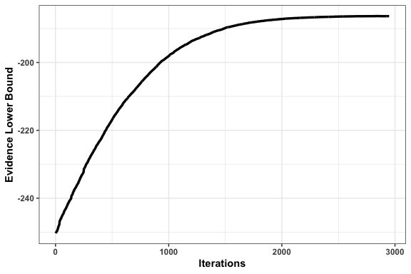

```r
plot(fit)
```

```r
extractELBO(fit, nsamples = 500)
```

```
#> [1] -186.665
```

The fitted surface at the observed exposures, and predictions at new ones, come back with their variational means; the true surface is recovered to the scale.

```r
fm <- fitted(fit, cov = FALSE)$fmean
cor(fm, h)
```

```
#>           [,1]
#> [1,] 0.9852313
```

```r
coef(lm(h ~ fm))
```

```
#> (Intercept)          fm
#>  0.03033199  1.03710032
```

```r
pr <- predict(fit, Z_new = Z[1:3, ], cov = FALSE)
pr$fmean
```

```
#>            [,1]
#> [1,] -0.4173542
#> [2,] -0.2888362
#> [3,]  0.9412770
```

### Exposure-response summaries

The single-exposure curves hold the other exposures at a quantile (`q.fixed`), the overall risk compares the surface with every exposure at a quantile against the median, and the single-variable risk asks how much one exposure moves the surface between two of its quantiles while the rest stay fixed. Each has a `plot()` method.

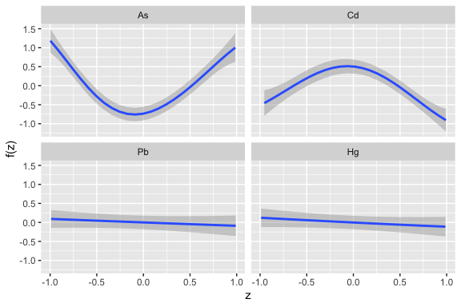

```r
univ <- predictorResponseUnivar(fit, ngrid = 25, nsamples = 300)
plot(univ)
```

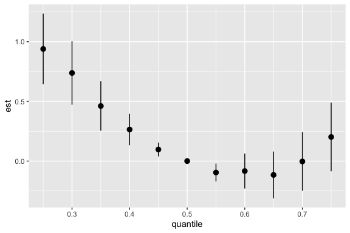

```r
risk <- computeOverallRisk(fit, qs = seq(0.25, 0.75, by = 0.05), nsamples = 300)
plot(risk)
```

```r
sv <- computeSingVarRisk(fit, which.z = 1:4, nsamples = 300)
sv$summary
```

```
#> # A tibble: 12 × 4
#>    q.fixed variable     est     sd
#>    <fct>   <fct>      <dbl>  <dbl>
#>  1 0.25    As       -0.961  0.184
#>  2 0.25    Cd       -0.711  0.156
#>  3 0.25    Pb       -0.0162 0.0923
#>  4 0.25    Hg       -0.198  0.110
#>  5 0.5     As       -0.293  0.143
#>  6 0.5     Cd       -0.243  0.145
#>  7 0.5     Pb       -0.0807 0.0821
#>  8 0.5     Hg       -0.119  0.0930
#>  9 0.75    As        0.147  0.166
#> 10 0.75    Cd        0.427  0.176
#> 11 0.75    Pb       -0.0966 0.0970
#> 12 0.75    Hg        0.0108 0.110
```

Two-exposure surfaces are drawn with `predictorResponseBivar()` and sliced at quantiles of the second exposure with `predictorResponseBivarLevels()`.

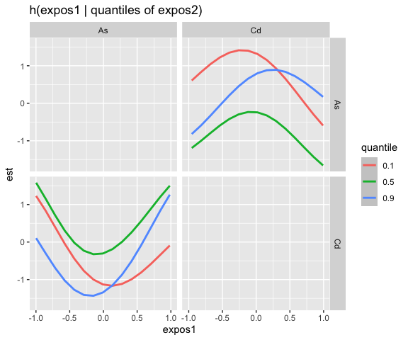

```r
biv <- predictorResponseBivar(fit, z.pairs = data.frame(z1 = 1, z2 = 2), ngrid = 15, nsamples = 300,
                              verbose = FALSE)
lev <- predictorResponseBivarLevels(biv, Z = Z, qs = c(0.1, 0.5, 0.9))
plot(lev)
```

### Which exposures matter

```r
fit.hs <- gvagpr(y, X, Z, priors = list(lengthscale = "horseshoe"),
                 minibatch = FALSE, verbose = FALSE, seed = 1)
computePPIPs(fit.hs, nsamples = 500)
```

```
#>   variable  PPIP
#> 1       As 0.998
#> 2       Cd 0.834
#> 3       Pb 0.000
#> 4       Hg 0.000
```

## Binary and count outcomes: `gvaggpr()`

The same model with a logit or log link, fitted through Pólya-Gamma augmentation and an inducing-point approximation to the process. The number of inducing points is `control$ninpts` (50 by default); the fits below use 30. The binary fit asks for the beta-prime shrinkage prior so that inclusion probabilities are available afterwards; the count fit keeps the default.

```r
yb <- rbinom(n, 1, plogis(0.5 * X[, "age"] + h))
fitb <- gvaggpr(yb, X, Z, family = binomial(), priors = list(lengthscale = "betaprime"),
                control = list(ninpts = 30), minibatch = FALSE, verbose = FALSE, seed = 1)
summary(fitb)
```

```
#> Fitted object of class 'gpr'
#> Outcome family: binomial ( logit )
#> Covariance structure: diagonal
#> Lengthscale Parameter: varying and shrinkage
#> Iterations: 8540
#> Running time: 6.393 secs
#> Model fit on: 2026-10-04 23:58:17.668425
#>
#> Parameter estimates:
#>           mean      sd    q_2.5    q_50  q_97.5
#> beta   0.49972 0.25600 -0.00166 0.50372 0.98766
#> lambda 3.13308 0.95734  1.70247 2.99293 5.25777
#> r1     1.99378 1.25120  0.50998 1.71124 5.19270
#> r2     0.91074 0.58140  0.24278 0.76722 2.60250
#> r3     0.80643 0.53332  0.23292 0.67876 1.98723
#> r4     0.73848 0.53118  0.19228 0.61267 2.02258
#>
#> Pseudo posterior inclusion probabilities:
#>   variable  PPIP
#> 1       As 0.842
#> 2       Cd 0.283
#> 3       Pb 0.207
#> 4       Hg 0.177
```

```r
yc <- rnbinom(n, size = 2, mu = exp(1 + 0.3 * X[, "age"] + 0.4 * h))
fitc <- gvaggpr(yc, X, Z, family = negbinomial(), control = list(ninpts = 30),
                minibatch = FALSE, verbose = FALSE, seed = 1)
summary(fitc)
```

```
#> Fitted object of class 'gpr'
#> Outcome family: negbinomial ( log )
#> Covariance structure: diagonal
#> Lengthscale Parameter: varying
#> Iterations: 25204
#> Running time: 14.671 secs
#> Model fit on: 2026-10-04 23:58:32.9319
#>
#> Parameter estimates:
#>           mean      sd   q_2.5    q_50  q_97.5
#> beta   0.40786 0.08038 0.25043 0.40912 0.56107
#> lambda 1.97728 0.44476 1.26077 1.92506 3.03831
#> r1     0.70162 0.23592 0.33958 0.67118 1.25357
#> r2     0.57189 0.21310 0.26546 0.53665 1.13294
#> r3     0.43881 0.15946 0.21586 0.41171 0.78746
#> r4     0.30795 0.13507 0.13321 0.28513 0.62467
#> theta  1.67998 0.28168 1.20836 1.65565 2.26758
```

The count fit estimates the dispersion of the negative binomial (`theta`, true value 2 here). Every tool above works on these fits as well:

```r
cor(fitted(fitb, cov = FALSE)$fmean, h)
```

```
#>           [,1]
#> [1,] 0.6978414
```

```r
computePPIPs(fitb, nsamples = 500)
```

```
#>   variable  PPIP
#> 1       As 0.844
#> 2       Cd 0.260
#> 3       Pb 0.234
#> 4       Hg 0.184
```

A count fit reports `c.unconverged`, the share of updates at which the inner fixed point of the Pólya-Gamma bound did not reach its tolerance within `control$cit` passes. On count data it is routinely close to one, because the tolerance sits below what double precision reaches there; it is a report, not a warning, and raising `cit` does not change the fit.

```r
fitc$c.unconverged
```

[output not shown]

## Random intercepts and slopes

Give `id` to add a random intercept per cluster, and `random.slope` (a column index of `X`) to add a random slope. The variational covariance of the fit is chosen with `covstr`: `"blockdiag"` keeps one block per cluster and one for the shared parameters, `"sparseprec"` uses a sparse precision factor whose cost grows linearly with the number of clusters, and `"diagonal"` is the mean field. Random-effects fits always use the whole sample.

```r
nID <- 20
id <- rep(seq_len(nID), each = n / nID)
b0 <- rnorm(nID, 0, 0.6)
yr <- rbinom(n, 1, plogis(0.5 * X[, "age"] + h + b0[id]))
## the caps on the optimiser keep the document quick (see the index section)
ctl <- list(ninpts = 30, max_iter = 4000, nws = 500, nsp = 30)
fitr <- gvaggpr(yr, X, Z, id = id, family = binomial(), covstr = "blockdiag",
                control = ctl, verbose = FALSE, seed = 1)
summary(fitr)
```

```
#> Fitted object of class 'gpr'
#> Outcome family: binomial ( logit )
#> Covariance structure: blockdiag
#> Lengthscale Parameter: varying
#> Random Effects: random intercept only
#> Iterations: 1925
#> Running time: 1.082 secs
#> Model fit on: 2026-10-04 23:58:34.396253
#>
#> Parameter estimates:
#>           mean      sd    q_2.5    q_50   q_97.5
#> beta   0.30778 0.17549 -0.03275 0.30680  0.66947
#> lambda 1.18587 0.63755  0.39287 1.06107  2.76924
#> r1     3.70332 4.17658  0.37831 2.42422 13.46233
#> r2     3.18273 4.16415  0.25565 1.82876 15.08904
#> r3     2.77564 4.13670  0.32617 1.75839 11.85834
#> r4     3.06251 4.55948  0.18626 1.66449 13.14236
#>
#> Variance estimates (random effects):
#>         [,1]
#> [1,] 0.67908
```

```r
re <- extractRandomEffects(fitr)
re$Sigma.b
```

```
#>           intercept
#> intercept 0.6790758
```

```r
cor(re$mean[, 1], b0)
```

```
#> [1] 0.6605432
```

`extractRandomEffects()` returns the variational mean and standard deviation of each cluster’s effects and their covariance `Sigma.b`; `summary()` prints the same covariance. With `random.slope = 1` the covariance is 2 x 2 and `re$mean` has a column per effect.

## The multiple index model: `gvagpmim()` and `gvaggpmim()`

```r
set.seed(7)
g1 <- matrix(runif(n * 3, -1, 1), n, 3, dimnames = list(NULL, c("As", "Cd", "Pb")))
g2 <- matrix(runif(n * 2, -1, 1), n, 2, dimnames = list(NULL, c("p1", "p2")))
g3 <- matrix(runif(n * 1, -1, 1), n, 1, dimnames = list(NULL, "s1"))
Zm <- list(metals = g1, phenols = g2, single = g3)
s1 <- as.numeric(g1 %*% c(0.8, 0.6, 0))        # Pb carries no weight
s2 <- as.numeric(g2 %*% c(0.7, 0.7))           # the third index carries nothing
hm <- (2 * s1 + 0.5)^2 - (2 * s2)^2
hm <- hm - mean(hm)
ym <- 0.5 * X[, "age"] + hm + rnorm(n, sd = 0.5)
fitm <- gvagpmim(ym, X, Zm, priors = list(lengthscale = "horseshoe"),
                 minibatch = FALSE, verbose = FALSE, seed = 1)
summary(fitm)
```

```
#> Fitted object of class 'gpmim'
#> Outcome family: gaussian
#> Covariance structure: diagonal
#> Lengthscale Parameter: varying and shrinkage
#> Iterations: 12456
#> Running time: 23.535 secs
#> Model fit on: 2026-10-04 23:58:58.018021
#>
#> Parameter estimates:
#>                    mean       sd     q_2.5      q_50    q_97.5
#> beta            0.50851  0.03396   0.44659   0.50617   0.57714
#> sigsq.eps       0.22917  0.02353   0.18833   0.22743   0.28062
#> lambda        233.98698 77.81718 119.56845 223.40630 421.57818
#> gamma.metals    0.24242  0.00520   0.23303   0.24225   0.25285
#> gamma.phenols   0.19607  0.00701   0.18307   0.19545   0.21047
#> gamma.single    0.00142  0.00648   0.00001   0.00028   0.00977
#> psi.As          0.39449  0.00511   0.38462   0.39437   0.40465
#> psi.Cd          0.29434  0.00523   0.28414   0.29426   0.30454
#> psi.Pb         -0.00388  0.00938  -0.02305  -0.00381   0.01366
#> psi.p1          0.31903  0.00601   0.30732   0.31894   0.33089
#> psi.p2          0.30675  0.01295   0.28166   0.30650   0.33232
#> psi.s1          0.02464  0.02845   0.00297   0.01672   0.09884
#> alpha.As        0.80128  0.00626   0.78946   0.80117   0.81327
#> alpha.Cd        0.59785  0.00834   0.58150   0.59818   0.61320
#> alpha.Pb       -0.00774  0.01897  -0.04600  -0.00772   0.02814
#> alpha.p1        0.72081  0.01860   0.68466   0.72068   0.75545
#> alpha.p2        0.69261  0.01937   0.65520   0.69327   0.72887
#> alpha.s1        1.00000  0.00000   1.00000   1.00000   1.00000
#>
#> Pseudo posterior inclusion probabilities:
#>   variable  PPIP   index index.PPIP
#> 1   metals 1.000    <NA>         NA
#> 2  phenols 1.000    <NA>         NA
#> 3   single 0.000    <NA>         NA
#> 4       As 1.000  metals          1
#> 5       Cd 1.000  metals          1
#> 6       Pb 0.000  metals          1
#> 7       p1 1.000 phenols          1
#> 8       p2 1.000 phenols          1
#> 9       s1 0.004  single          0
```

`computePPIPs()` on an index fit gives one probability per index and one per exposure within its index: here the metals and phenols indices, and within the metals As and Cd, should be in, and Pb and the third index out.

```r
computePPIPs(fitm, nsamples = 500)
```

```
#>   variable  PPIP   index index.PPIP
#> 1   metals 1.000    <NA>         NA
#> 2  phenols 1.000    <NA>         NA
#> 3   single 0.000    <NA>         NA
#> 4       As 1.000  metals          1
#> 5       Cd 1.000  metals          1
#> 6       Pb 0.000  metals          1
#> 7       p1 1.000 phenols          1
#> 8       p2 1.000 phenols          1
#> 9       s1 0.004  single          0
```

The binary and count versions take `family`. Their bound integrates the inducing values out, so the fit is in the index weights, the length-scales and the coefficients only; `fitted()` and `predict()` rebuild the surface. These fits run tens of thousands of updates before the stopping rule is satisfied, so the two below are capped with the same `ctl` as the random-effects fit above (`max_iter`, `nws`, `nsp`) to keep the document quick; the weights they return are already close to where the full run ends.

```r
ymb <- rbinom(n, 1, plogis(0.5 * X[, "age"] + 0.7 * hm))
fitmb <- gvaggpmim(ymb, X, Zm, family = binomial(), control = ctl,
                   minibatch = FALSE, verbose = FALSE, seed = 1)
summary(fitmb)
```

```
#> Fitted object of class 'gpmim'
#> Outcome family: binomial ( logit )
#> Covariance structure: fullrank
#> Lengthscale Parameter: varying and shrinkage
#> Iterations: 4000
#> Running time: 18.464 secs
#> Model fit on: 2026-10-04 23:59:17.616215
#>
#> Parameter estimates:
#>                  mean      sd    q_2.5    q_50  q_97.5
#> beta          0.49086 0.14723  0.21389 0.49106 0.78549
#> lambda        4.40019 0.95284  2.80092 4.31714 6.56452
#> gamma.metals  0.43981 0.15178  0.19367 0.42769 0.77121
#> gamma.phenols 0.57221 0.18362  0.30270 0.54683 1.00622
#> gamma.single  0.01673 0.00731  0.00663 0.01561 0.03516
#> psi.As        0.45872 0.12547  0.21364 0.45263 0.70264
#> psi.Cd        0.40907 0.12971  0.14561 0.41047 0.66959
#> psi.Pb        0.09573 0.14270 -0.18032 0.09649 0.36427
#> psi.p1        0.48986 0.10168  0.29482 0.48920 0.68844
#> psi.p2        0.55317 0.12620  0.33943 0.54096 0.83691
#> psi.s1        0.12650 0.02698  0.08141 0.12492 0.18751
#> alpha.As      0.69976 0.13934  0.36722 0.71612 0.92168
#> alpha.Cd      0.62296 0.15819  0.26161 0.63643 0.88609
#> alpha.Pb      0.16437 0.22560 -0.22890 0.15250 0.63411
#> alpha.p1      0.65861 0.11163  0.42631 0.66364 0.85322
#> alpha.p2      0.73731 0.10086  0.52154 0.74805 0.90458
#> alpha.s1      1.00000 0.00000  1.00000 1.00000 1.00000
#>
#> Pseudo posterior inclusion probabilities:
#>   variable  PPIP   index index.PPIP
#> 1   metals 0.810    <NA>         NA
#> 2  phenols 0.982    <NA>         NA
#> 3   single 0.000    <NA>         NA
#> 4       As 0.816  metals      0.810
#> 5       Cd 0.698  metals      0.810
#> 6       Pb 0.045  metals      0.810
#> 7       p1 0.910 phenols      0.982
#> 8       p2 0.962 phenols      0.982
#> 9       s1 0.000  single      0.000
```

```r
cor(fitted(fitmb, cov = FALSE)$fmean, hm)
```

```
#>           [,1]
#> [1,] 0.9598969
```

The index model takes random effects in the same way as the basic one:

```r
ymr <- rnbinom(n, size = 2, mu = exp(1.5 + 0.4 * X[, "age"] + 0.4 * hm + b0[id]))
fitmr <- gvaggpmim(ymr, X, Zm, id = id, family = negbinomial(), covstr = "blockdiag",
                   control = c(ctl[c("ninpts", "nws", "nsp")], max_iter = 8000),
                   verbose = FALSE, seed = 1)
summary(fitmr)
```

```
#> Fitted object of class 'gpmim'
#> Outcome family: negbinomial ( log )
#> Covariance structure: blockdiag
#> Lengthscale Parameter: varying and shrinkage
#> Random Effects: random intercept only
#> Iterations: 3127
#> Running time: 16.887 secs
#> Model fit on: 2026-10-04 23:59:35.473938
#>
#> Parameter estimates:
#>                   mean      sd    q_2.5     q_50   q_97.5
#> beta           0.33397 0.05592  0.22482  0.33360  0.44071
#> lambda         4.90604 2.48831  1.71525  4.36129 11.01771
#> gamma.metals   0.37344 0.11312  0.17793  0.36501  0.60688
#> gamma.phenols  0.35244 0.11786  0.17742  0.33491  0.62015
#> gamma.single   0.00838 0.01698  0.00024  0.00338  0.05346
#> psi.As         0.43397 0.07518  0.28483  0.43509  0.57874
#> psi.Cd         0.41565 0.07161  0.27441  0.41267  0.55171
#> psi.Pb        -0.01589 0.03642 -0.08552 -0.01775  0.05777
#> psi.p1         0.44242 0.07554  0.29509  0.44298  0.59094
#> psi.p2         0.38071 0.07792  0.25213  0.37060  0.55269
#> psi.s1         0.07282 0.05546  0.01539  0.05818  0.23122
#> alpha.As       0.71819 0.05267  0.60912  0.71956  0.81831
#> alpha.Cd       0.68839 0.05530  0.57084  0.69115  0.79078
#> alpha.Pb      -0.02332 0.06282 -0.13210 -0.02941  0.10612
#> alpha.p1       0.75612 0.05533  0.64639  0.75800  0.85692
#> alpha.p2       0.64887 0.06476  0.51545  0.65225  0.76301
#> alpha.s1       1.00000 0.00000  1.00000  1.00000  1.00000
#> theta          2.48860 0.39572  1.82047  2.44758  3.34760
#>
#> Variance estimates (random effects):
#>         [,1]
#> [1,] 0.34818
#>
#> Pseudo posterior inclusion probabilities:
#>   variable  PPIP   index index.PPIP
#> 1   metals 0.965    <NA>         NA
#> 2  phenols 0.945    <NA>         NA
#> 3   single 0.000    <NA>         NA
#> 4       As 0.996  metals      0.965
#> 5       Cd 0.991  metals      0.965
#> 6       Pb 0.000  metals      0.965
#> 7       p1 0.995 phenols      0.945
#> 8       p2 0.970 phenols      0.945
#> 9       s1 0.019  single      0.000
```

```r
extractRandomEffects(fitmr)$Sigma.b
```

```
#>           intercept
#> intercept 0.3481782
```

## Mini-batches

`minibatch = TRUE` (the default) fits the fixed-effects models by stochastic optimisation on batches of the data, which caps the cost of an update as `n` grows. The split is `control$batch.size` for the continuous and count models; a binary index model fixes it at 150 and asks for at least five hundred observations, below which it warns and should be given `minibatch = FALSE` as above. Random-effects fits ignore `minibatch`. The posterior summaries are the same whichever way the fit was made.

## Settings, reproducibility and diagnostics

- `seed` fixes the variational fit exactly: two calls with the same data and seed return the same object to the last digit, on every platform.
- `control` carries the optimiser settings: `max_iter`, the smoothing window `nws` and the patience `nsp` of the stopping rule, `ninpts` and `cit` for the Pólya-Gamma fits. `plot(fit)` shows whether the bound had settled.
- A Pólya-Gamma index fit also reports `cond.K_IP`, the condition number of its inducing-point kernel at the returned length-scales.
- If a covariance matrix inside a bound cannot be factorised at some point of the optimisation, the fit stops with an error rather than returning a value; a different seed, fewer exposures or a smaller `ninpts` usually clears it.